# Análisis Numérico- Laura Jimenez - Sebastián Gutierrez - Paula Sánchez

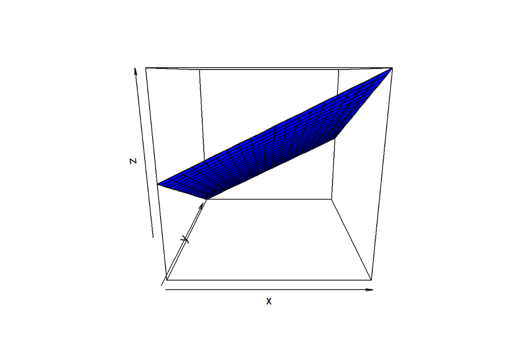

```r
z <- outer(x, y, e3)
persp(x, y, z,col="blue")
```

6. Instalar el paquete Matrix y descomponga la matriz $A$ (del punto dos) de la forma $LU$ y la factorizarla como $A=QR$

```r
A = matrix(c(-8.1, -7, 6.123, -2,
             -1, 4,-3, -1,
             0, -1, -5, 0.6,
             -1, 0.33, 6, 1/2), nrow=4, byrow=TRUE)
A
```

```
##      [,1]  [,2]   [,3] [,4]
## [1,] -8.1 -7.00  6.123 -2.0
## [2,] -1.0  4.00 -3.000 -1.0
## [3,]  0.0 -1.00 -5.000  0.6
## [4,] -1.0  0.33  6.000  0.5
```

```r
b = matrix(c(1.45,3,5.12,-4), nrow=4, byrow=TRUE)
b
```

```
##       [,1]
## [1,]  1.45
## [2,]  3.00
## [3,]  5.12
## [4,] -4.00
```

```r
Ab = cbind(A,b)
print(Ab)
```

```
##      [,1]  [,2]   [,3] [,4]  [,5]
## [1,] -8.1 -7.00  6.123 -2.0  1.45
## [2,] -1.0  4.00 -3.000 -1.0  3.00
## [3,]  0.0 -1.00 -5.000  0.6  5.12
## [4,] -1.0  0.33  6.000  0.5 -4.00
```

```r
#matrices necesarias
I<-eye(4, m = 4)
U = upper.tri(A, diag=FALSE)%*%A
L = lower.tri(A, diag=FALSE)%*%A
D = I%*%A

#factorizacion A = QR
gs <- gramSchmidt(A)
(Q <- gs$Q); (R <- gs$R)
```

```
##            [,1]       [,2]        [,3]        [,4]
## [1,] -0.9850983 -0.1436118 -0.04743408 -0.08189671
## [2,] -0.1216171  0.9447015 -0.30403534 -0.01763100
## [3,]  0.0000000 -0.1978603 -0.65697987  0.72748111
## [4,] -0.1216171  0.2185544  0.68825138  0.68099435
```

```
##         [,1]     [,2]      [,3]       [,4]
## [1,] 8.22253 6.369086 -6.396608  2.0310050
## [2,] 0.00000 5.054072 -1.412812 -0.6669168
## [3,] 0.00000 0.000000  8.036075  0.3488413
## [4,] 0.00000 0.000000  0.000000  0.9584103
```

```r
if(all(Q%*%R == A))
{
  cat("comprobado")
}
```

[output not shown]

1. Determinar numéricamente la intersección entre la circunferencia $x^2 + y^2 = 1$ y la recta $y = x$. Usamos una aproximación inicial $(1,1)$. Utilice el pauqte BB y la función BBsolve() del paquete,grafique la solución

```r
library(BB)
ecuaciones = function(x) {
  n = length(x)
  F = rep(NA, n)
  F[1] = x[1] - x[2]
  F[2] = x[1]^2 + x[2]^2 -1
  F
}
p0 = c(1,1) # n initial starting guess
sol = BBsolve(par=p0, fn=ecuaciones)
```

```
##   Successful convergence.
```

```r
sol$par
```

```
## [1] 0.7071067 0.7071068
```

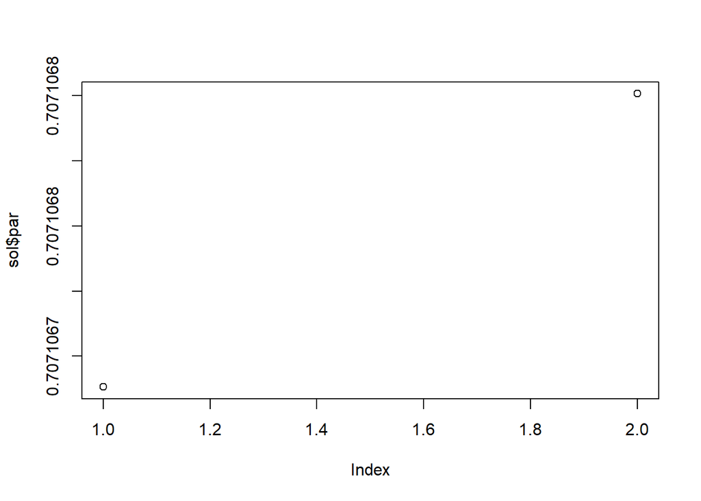

```r
plot(sol$par)
```

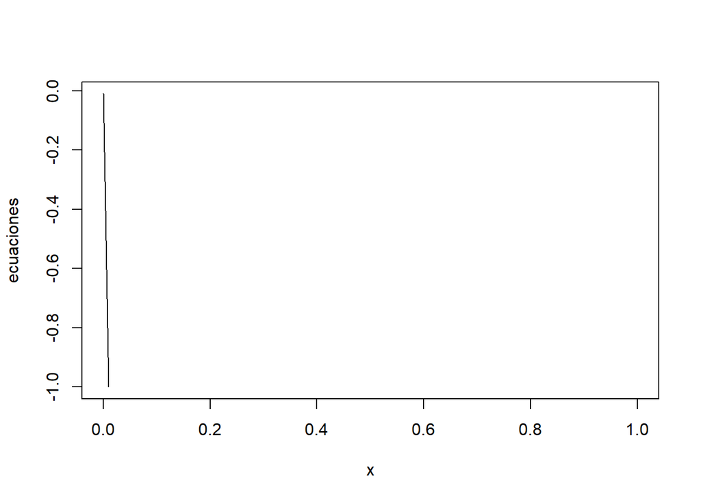

```r
plot(ecuaciones)
```

b Analizar y comentar el siguinte código

```r
trigexp = function(x) {
#obtener el numero de variables del sistema
n = length(x)
# Llenar F con n elementos vacios
F = rep(NA, n)
#Ingreso de ecuaciones:  F[1] = 3(x_1)^2 + 2(x_2) - 5 + sin( (x_1)-(x_2) )( sin( (x_1)+(x_2) ) )
F[1] = 3*x[1]^2 + 2*x[2] - 5 + sin(x[1] - x[2]) * sin(x[1] + x[2])
#a tn1 se le asigna una secuencia de 2 hasta n-1
tn1 = 2:(n-1)
#Se ingresan |tn1| ecuaciones, es decir desde la ecuación 2 hasta la n-1
F[tn1] = -x[tn1-1] * exp(x[tn1-1] - x[tn1]) + x[tn1] *
( 4 + 3*x[tn1]^2) + 2 * x[tn1 + 1] + sin(x[tn1] -
x[tn1 + 1]) * sin(x[tn1] + x[tn1 + 1]) - 8
#Se ingresa la ecuación n
F[n] = -x[n-1] * exp(x[n-1] - x[n]) + 4*x[n] - 3
F
}
```

[output not shown]

8. Demuestre y realice varias pruebas que la matriz de transición por el método de Gauss-Seidel esta dada por $T=(-D^{-1}U)(I+LD^{-1})^{-1}$

Se tiene en cuenta la definición de convergencia del error de entrucamiento de la forma:

$E^{k+1}=TE^k$

Si se opera el lado izquierdo de la ecuación se llega a la expresión:

$X-X^{K+1}=-D^{-1}L(X-x^{k+1})-UD^{-1}(X-X^K)$

$E^{k+1}=-D^{-1}LE^{k+1}-UD^{-1}E^K$

$E^{k+1}+D^{-1}LE^{k+1}=-UD^{-1}E^{k}$

$E^{k+1}(I+D^{-1}L)=-D^{-1}UE^k$

Con esto se llega a la expresión final:

$E^{k+1}=(-D^{-1}U)(I+D^{-1}L)^{-1}E^k$

Reemplazando esta expresión en la expresión de definición de convergencia, se tiene que la matriz de transición T es: